## Pytanie o przyczynienie się:

### Wykres

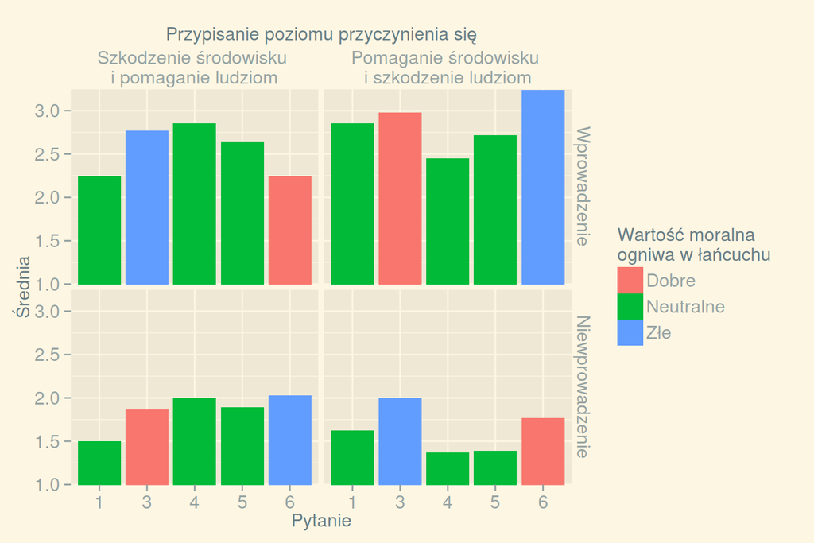

### Test Wilcoxona pomiędzy pytaniem 5 (śmierć głodowa) a pytaniem 2 (środowisko)

#### Harm & Introduced

```
##
##  Wilcoxon rank sum test with continuity correction
##
## data:  data_S[which(data_S$V1 == "Harm" & data_S$V2 == "Introduced" &  and data_S[which(data_S$V1 == "Harm" & data_S$V2 == "Introduced" &     data_S$PYTANIE == "5"), ]$V3 and     data_S$PYTANIE == "2"), ]$V3
## W = 927.5, p-value = 0.09025
## alternative hypothesis: true location shift is not equal to 0
```

#### Help & Introduced

```
##
##  Wilcoxon rank sum test with continuity correction
##
## data:  data_S[which(data_S$V1 == "Help" & data_S$V2 == "Introduced" &  and data_S[which(data_S$V1 == "Help" & data_S$V2 == "Introduced" &     data_S$PYTANIE == "5"), ]$V3 and     data_S$PYTANIE == "2"), ]$V3
## W = 1020, p-value = 0.1837
## alternative hypothesis: true location shift is not equal to 0
```

#### Harm & Not introduced

```
##
##  Wilcoxon rank sum test with continuity correction
##
## data:  data_S[which(data_S$V1 == "Harm" & data_S$V2 == "Not introduced" &  and data_S[which(data_S$V1 == "Harm" & data_S$V2 == "Not introduced" &     data_S$PYTANIE == "5"), ]$V3 and     data_S$PYTANIE == "2"), ]$V3
## W = 3103.5, p-value = 0.4167
## alternative hypothesis: true location shift is not equal to 0
```

#### Help & Not introduced

```
##
##  Wilcoxon rank sum test with continuity correction
##
## data:  data_S[which(data_S$V1 == "Help" & data_S$V2 == "Not introduced" &  and data_S[which(data_S$V1 == "Help" & data_S$V2 == "Not introduced" &     data_S$PYTANIE == "5"), ]$V3 and     data_S$PYTANIE == "2"), ]$V3
## W = 1200, p-value = 0.4904
## alternative hypothesis: true location shift is not equal to 0
```

## Test Wilcoxona dla globalnej różnicy, tzn. różnicy między wszystkimi pytaniami.

### Introduced

```
##
##  Wilcoxon rank sum test with continuity correction
##
## data:  data_S[which(data_S$V1 == "Help" & data_S$V2 == "Introduced"),  and data_S[which(data_S$V1 == "Harm" & data_S$V2 == "Introduced"),     ]$V3 and     ]$V3
## W = 28059, p-value = 0.03051
## alternative hypothesis: true location shift is not equal to 0
```

### Not introduced

```
##
##  Wilcoxon rank sum test with continuity correction
##
## data:  data_S[which(data_S$V1 == "Help" & data_S$V2 == "Not introduced"),  and data_S[which(data_S$V1 == "Harm" & data_S$V2 == "Not introduced"),     ]$V3 and     ]$V3
## W = 43164, p-value = 0.01683
## alternative hypothesis: true location shift is not equal to 0
```

### Analiza wariancji ANOVA

```
## Anova Table (Type II tests)
##
## Response: V3
##                Sum Sq   Df  F value    Pr(>F)
## V1               0.01    1   0.0054  0.941371
## V2             224.20    1 111.0514 < 2.2e-16 ***
## PYTANIE         16.48    4   2.0402  0.086679 .
## V1:V2           17.46    1   8.6503  0.003341 **
## V1:PYTANIE      29.53    4   3.6567  0.005754 **
## V2:PYTANIE       1.64    4   0.2036  0.936464
## V1:V2:PYTANIE   10.62    4   1.3157  0.262155
## Residuals     2150.12 1065
## ---
## Signif. codes:  0 '***' 0.001 '**' 0.01 '*' 0.05 '.' 0.1 ' ' 1
```

```
##
## Study: fit ~ c("V1", "V2", "PYTANIE")
##
## HSD Test for V3
##
## Mean Square Error:  2.01889
##
## V1:V2:PYTANIE,  means
##
##                             V3      std  r Min Max
## Harm:Introduced:1     2.250000 1.494671 48   0   4
## Harm:Introduced:2     2.770833 1.275624 48   0   4
## Harm:Introduced:3     2.854167 1.237526 48   0   4
## Harm:Introduced:4     2.645833 1.436449 48   0   4
## Harm:Introduced:5     2.250000 1.480368 48   0   4
## Harm:Not introduced:1 1.500000 1.331666 76   0   4
## Harm:Not introduced:2 1.868421 1.445380 76   0   4
## Harm:Not introduced:3 2.000000 1.514376 76   0   4
## Harm:Not introduced:4 1.894737 1.465869 76   0   4
## Harm:Not introduced:5 2.026316 1.243368 76   0   4
## Help:Introduced:1     2.857143 1.335654 42   0   4
## Help:Introduced:2     2.976190 1.115043 42   0   4
## Help:Introduced:3     2.452381 1.382863 42   0   4
## Help:Introduced:4     2.714286 1.311966 42   0   4
## Help:Introduced:5     3.238095 1.122052 42   0   4
## Help:Not introduced:1 1.627451 1.535719 51   0   4
## Help:Not introduced:2 2.000000 1.600000 51   0   4
## Help:Not introduced:3 1.372549 1.648767 51   0   4
## Help:Not introduced:4 1.392157 1.511005 51   0   4
## Help:Not introduced:5 1.764706 1.656360 51   0   4
##
## alpha: 0.05 ; Df Error: 1065
## Critical Value of Studentized Range: 5.024513
##
## Harmonic Mean of Cell Sizes  51.67385
## Honestly Significant Difference: 0.9931501
##
## Means with the same letter are not significantly different.
##
## Groups, Treatments and means
## a     Help:Introduced:5       3.238
## ab    Help:Introduced:2       2.976
## abc   Help:Introduced:1       2.857
## abc   Harm:Introduced:3       2.854
## abcd      Harm:Introduced:2       2.771
## abcd      Help:Introduced:4       2.714
## abcd      Harm:Introduced:4       2.646
## abcde     Help:Introduced:3       2.452
## abcdef    Harm:Introduced:1       2.25
## abcdef    Harm:Introduced:5       2.25
## bcdef     Harm:Not introduced:5   2.026
## cdef      Harm:Not introduced:3   2
## cdef      Help:Not introduced:2   2
## cdef      Harm:Not introduced:4   1.895
## def   Harm:Not introduced:2   1.868
## def   Help:Not introduced:5   1.765
## ef    Help:Not introduced:1   1.627
## ef    Harm:Not introduced:1   1.5
## f     Help:Not introduced:4   1.392
## f     Help:Not introduced:3   1.373
```

### Różnice statystyczne między pytaniem 5 Harm vs Help: Introduced

```
##
##  Wilcoxon rank sum test with continuity correction
##
## data:  data_S[which(data_S$V1 == "Help" & data_S$V2 == "Introduced" &  and data_S[which(data_S$V1 == "Harm" & data_S$V2 == "Introduced" &     data_S$PYTANIE == "5"), ]$V3 and     data_S$PYTANIE == "5"), ]$V3
## W = 1390, p-value = 0.001187
## alternative hypothesis: true location shift is not equal to 0
```

Jest istotna statystycznie różnica. Uwaga: Jest też na granicy istotności różnica w pytaniu 1! (p=,05xxx)

### Różnice statystyczne między pytaniem 5 Harm vs Help: Not introduced

```
##
##  Wilcoxon rank sum test with continuity correction
##
## data:  data_S[which(data_S$V1 == "Help" & data_S$V2 == "Not introduced" &  and data_S[which(data_S$V1 == "Harm" & data_S$V2 == "Not introduced" &     data_S$PYTANIE == "5"), ]$V3 and     data_S$PYTANIE == "5"), ]$V3
## W = 1709.5, p-value = 0.252
## alternative hypothesis: true location shift is not equal to 0
```

Nie ma istotnie statystycznej różnicy. Uwaga: Jest różnica w 3 i 4! Dlaczego? nie wiem!

## SPRAWSTWO

### Wykres dla sprawstwa

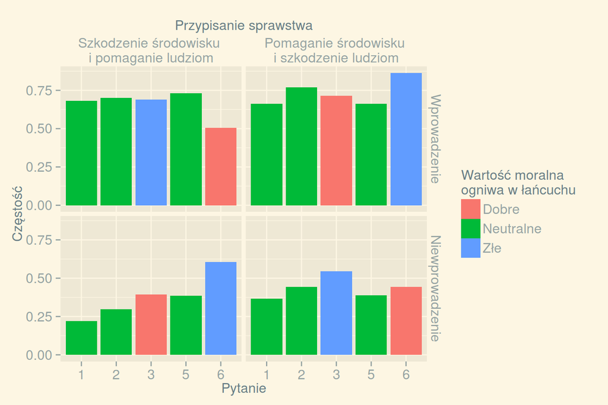

### Test Chi^2 pomiędzy pytaniem 5 (śmierć głodowa) a pytaniem 3 (środowisko)

#### Harm & Introduced

```
##
##  Pearson's Chi-squared test with Yates' continuity correction
##
## data:  as.factor(agency_data[which(agency_data$V1 == "Harm" & agency_data$V2 ==
##     "Introduced" & agency_data$PYTANIE %in% c("3", "5")), ]$V3) and as.factor(agency_data[which(agency_data$V1 == "Harm" & agency_data$V2 ==
##     "Introduced" & agency_data$PYTANIE %in% c("3", "5")), ]$PYTANIE)
## X-squared = 6.1965, df = 1, p-value = 0.0128
```

#### Help & Introduced

```
##
##  Pearson's Chi-squared test with Yates' continuity correction
##
## data:  as.factor(agency_data[which(agency_data$V1 == "Help" & agency_data$V2 ==
##     "Introduced" & agency_data$PYTANIE %in% c("3", "5")), ]$V3) and as.factor(agency_data[which(agency_data$V1 == "Help" & agency_data$V2 ==
##     "Introduced" & agency_data$PYTANIE %in% c("3", "5")), ]$PYTANIE)
## X-squared = 5.3517, df = 1, p-value = 0.0207
```

#### Harm & Not introduced

```
##
##  Pearson's Chi-squared test with Yates' continuity correction
##
## data:  as.factor(agency_data[which(agency_data$V1 == "Harm" & agency_data$V2 ==
##     "Not introduced" & agency_data$PYTANIE %in% c("3", "5")),
##     ]$V3) and as.factor(agency_data[which(agency_data$V1 == "Harm" & agency_data$V2 ==
##     "Not introduced" & agency_data$PYTANIE %in% c("3", "5")),
##     ]$PYTANIE)
## X-squared = 8.4808, df = 1, p-value = 0.003589
```

#### Help & Not introduced

```
##
##  Pearson's Chi-squared test with Yates' continuity correction
##
## data:  as.factor(agency_data[which(agency_data$V1 == "Help" & agency_data$V2 ==
##     "Not introduced" & agency_data$PYTANIE %in% c("3", "5")),
##     ]$V3) and as.factor(agency_data[which(agency_data$V1 == "Help" & agency_data$V2 ==
##     "Not introduced" & agency_data$PYTANIE %in% c("3", "5")),
##     ]$PYTANIE)
## X-squared = 1.4224, df = 1, p-value = 0.233
```

### Testy chi^2 dla różnicy globalnej

#### Introduced

```
##
##  Pearson's Chi-squared test with Yates' continuity correction
##
## data:  V1 and V3
## X-squared = 5.7052, df = 1, p-value = 0.01691
```

#### Not introduced

```
##
##  Pearson's Chi-squared test with Yates' continuity correction
##
## data:  V1 and V3
## X-squared = 3.016, df = 1, p-value = 0.08245
```

### Testy chi^2 dla różnicy między scenariuszami Harm i Help w pytaniu 5 (ludzie)

#### Introduced

```
##
##  Pearson's Chi-squared test with Yates' continuity correction
##
## data:  as.factor(agency_data[which(agency_data$V2 == "Introduced" &
##     agency_data$PYTANIE %in% c("5")), ]$V3) and as.factor(agency_data[which(agency_data$V2 == "Introduced" &
##     agency_data$PYTANIE %in% c("5")), ]$V1)
## X-squared = 26.75, df = 1, p-value = 2.316e-07
```

#### Not introduced

```
##
##  Pearson's Chi-squared test with Yates' continuity correction
##
## data:  as.factor(agency_data[which(agency_data$V2 == "Not introduced" &
##     agency_data$PYTANIE %in% c("5")), ]$V3) and as.factor(agency_data[which(agency_data$V2 == "Not introduced" &
##     agency_data$PYTANIE %in% c("5")), ]$V1)
## X-squared = 4.415, df = 1, p-value = 0.03562
```

Uwaga: Tylko pomiędzy tymi pytaniami jest istotna statystycznie różnica! Więc ważna!

## Intencjonalność

### Wykres

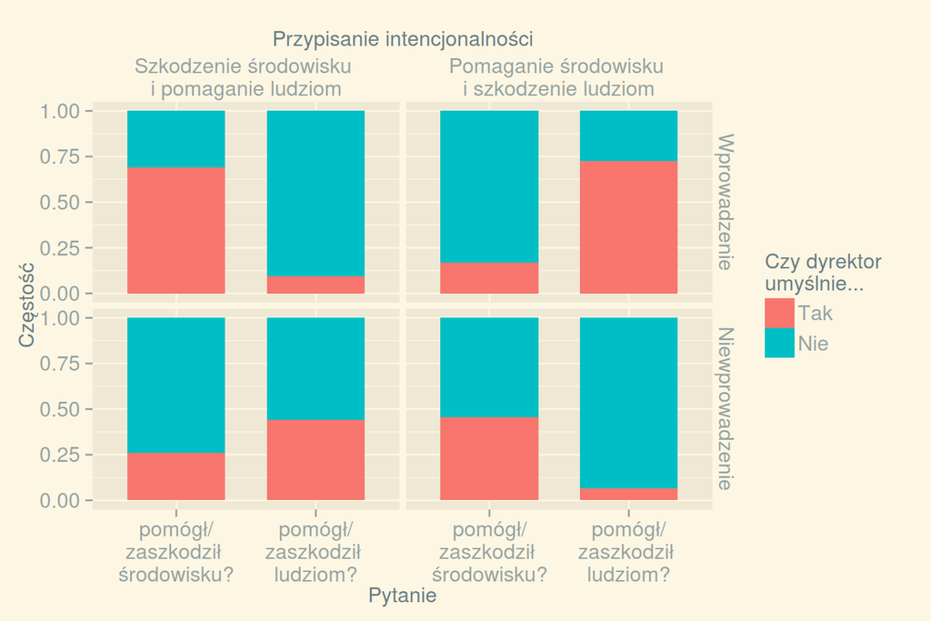

### Test Chi^2 pomiędzy poszczególnymi grupami

#### Efekt Knobe’a miedzy grupami

```
##
##  Pearson's Chi-squared test with Yates' continuity correction
##
## data:  data_intentionality[which(data_intentionality$V2 == "Introduced"),
##     ]$V3 and data_intentionality[which(data_intentionality$V2 == "Introduced"),
##     ]$V1
## X-squared = 51.243, df = 1, p-value = 8.162e-13
```

```
##
##  Pearson's Chi-squared test with Yates' continuity correction
##
## data:  data_intentionality[which(data_intentionality$V2 == "Introduced"),
##     ]$V4 and data_intentionality[which(data_intentionality$V2 == "Introduced"),
##     ]$V1
## X-squared = 77.256, df = 1, p-value < 2.2e-16
```

```
##
##  Pearson's Chi-squared test with Yates' continuity correction
##
## data:  data_intentionality[which(data_intentionality$V2 == "Not introduced"),
##     ]$V3 and data_intentionality[which(data_intentionality$V2 == "Not introduced"),
##     ]$V1
## X-squared = 7.2987, df = 1, p-value = 0.0069
```

```
##
##  Pearson's Chi-squared test with Yates' continuity correction
##
## data:  data_intentionality[which(data_intentionality$V2 == "Not introduced"),
##     ]$V4 and data_intentionality[which(data_intentionality$V2 == "Not introduced"),
##     ]$V1
## X-squared = 32.812, df = 1, p-value = 1.015e-08
```

#### Efekt Knobe’a w obrębie grup

```
##
##  Pearson's Chi-squared test with Yates' continuity correction
##
## data:  c(data_intentionality[which(data_intentionality$V1 == "Harm" &
##     data_intentionality$V2 == "Introduced"), ]$V3, data_intentionality[which(data_intentionality$V1 ==
##     "Harm" & data_intentionality$V2 == "Introduced"), ]$V4) and c(rep("ENV", length(data_intentionality[which(data_intentionality$V1 ==
##     "Harm" & data_intentionality$V2 == "Introduced"), ]$V3)),
##     rep("STV", length(data_intentionality[which(data_intentionality$V1 ==
##         "Harm" & data_intentionality$V2 == "Introduced"), ]$V4)))
## X-squared = 70.284, df = 1, p-value < 2.2e-16
```

```
##
##  Pearson's Chi-squared test with Yates' continuity correction
##
## data:  c(data_intentionality[which(data_intentionality$V1 == "Help" &
##     data_intentionality$V2 == "Introduced"), ]$V3, data_intentionality[which(data_intentionality$V1 ==
##     "Help" & data_intentionality$V2 == "Introduced"), ]$V4) and c(rep("ENV", length(data_intentionality[which(data_intentionality$V1 ==
##     "Help" & data_intentionality$V2 == "Introduced"), ]$V3)),
##     rep("STV", length(data_intentionality[which(data_intentionality$V1 ==
##         "Help" & data_intentionality$V2 == "Introduced"), ]$V4)))
## X-squared = 57.564, df = 1, p-value = 3.271e-14
```

```
##
##  Pearson's Chi-squared test with Yates' continuity correction
##
## data:  c(data_intentionality[which(data_intentionality$V1 == "Harm" &
##     data_intentionality$V2 == "Not introduced"), ]$V3, data_intentionality[which(data_intentionality$V1 ==
##     "Harm" & data_intentionality$V2 == "Not introduced"), ]$V4) and c(rep("ENV", length(data_intentionality[which(data_intentionality$V1 ==
##     "Harm" & data_intentionality$V2 == "Not introduced"), ]$V3)),
##     rep("STV", length(data_intentionality[which(data_intentionality$V1 ==
##         "Harm" & data_intentionality$V2 == "Not introduced"),
##         ]$V4)))
## X-squared = 6.8384, df = 1, p-value = 0.008922
```

```
##
##  Pearson's Chi-squared test with Yates' continuity correction
##
## data:  c(data_intentionality[which(data_intentionality$V1 == "Help" &
##     data_intentionality$V2 == "Not introduced"), ]$V3, data_intentionality[which(data_intentionality$V1 ==
##     "Help" & data_intentionality$V2 == "Not introduced"), ]$V4) and c(rep("ENV", length(data_intentionality[which(data_intentionality$V1 ==
##     "Help" & data_intentionality$V2 == "Not introduced"), ]$V3)),
##     rep("STV", length(data_intentionality[which(data_intentionality$V1 ==
##         "Help" & data_intentionality$V2 == "Not introduced"),
##         ]$V4)))
## X-squared = 33.287, df = 1, p-value = 7.949e-09
```

Jest różnica wszędzie!!

## Pytania Kusiołka :)

*Pytanie*: Czy w scenariuszach z wprowadzaniem w jakiś sposób mniej się przyczynił do tych ogniw, które są dalej od dyrektora.

*Odpowiedź* Tak ogólnie to raczej nie i nie trzeba liczyć, wyraźnie widać na wykresie.

*Pytanie* Jeśli dystans nie będzie miał znaczenia, to należy spojrzeć na to, czy się nie wybijają nacechowane moralnie. Jeśli się wybijają na plus harmy (czyli jeśli do szkodzenia środowisku (drugie ogniwo) bardziej się przyczynił i sprawił niż a) do tego, co w ogniwie pierwszym i b) niż do tego, co w ogniwie trzecim), a na minus helpy (mniej się przyczynił i sprawił pomożenie środowisku niż to, co jest a) w ogniwie pierwszym i b) niż to, co jest w ogniwie trzecim) – to mamy efekt Knobe’a pewien. Podobnie z przyczynianiem się do śmierci (jeśli się wybija, że bardziej się przyczynił do śmierci niż do wcześniejszych ogniw neutralnych) i z uwalnianiem od śmierci (jeśli się wybija na minus od neutralnych).

*Odpowiedź* Częściowo odpowiadam na to pytanie już wyżej, szczególnie zob. porównywanie międzygrupami tych samych pytań, co wydaje mi się lepszą strategią niż to, co napisałaś.

*Pytanie* Czy ogólnie rzecz biorąc mniej przypisuje się średnio przyczynowości przy niewprowadzaniu niż przy wprowadzaniu?

*Odpowiedź* Tak.

```
##
## Study: fit ~ c("V2")
##
## HSD Test for V3
##
## Mean Square Error:  2.01889
##
## V2,  means
##
##                      V3      std   r Min Max
## Introduced     2.691111 1.349804 450   0   4
## Not introduced 1.766929 1.489980 635   0   4
##
## alpha: 0.05 ; Df Error: 1065
## Critical Value of Studentized Range: 2.774961
##
## Harmonic Mean of Cell Sizes  526.7281
## Honestly Significant Difference: 0.1717988
##
## Means with the same letter are not significantly different.
##
## Groups, Treatments and means
## a     Introduced          2.691
## b     Not introduced      1.767
```

*Pyanie* Czy jak się popatrzy parami na neutralne ogniwa w sensie pierwsze ogniowo introd. porówna z pierwszym nieintrod (niszczenie wałów contra nieniszczenie wałów), a trzecie z trzecim i czwarte z czwartym, to w większości wypadków tam, gdzie introduce większa przyczynowość.

*Odpowiedź* Tak.

```
##
## Study: fit ~ c("V2", "PYTANIE")
##
## HSD Test for V3
##
## Mean Square Error:  2.01889
##
## V2:PYTANIE,  means
##
##                        V3      std   r Min Max
## Introduced:1     2.533333 1.447198  90   0   4
## Introduced:2     2.866667 1.201123  90   0   4
## Introduced:3     2.666667 1.315423  90   0   4
## Introduced:4     2.677778 1.372505  90   0   4
## Introduced:5     2.711111 1.408198  90   0   4
## Not introduced:1 1.551181 1.412578 127   0   4
## Not introduced:2 1.921260 1.504524 127   0   4
## Not introduced:3 1.748031 1.593481 127   0   4
## Not introduced:4 1.692913 1.498739 127   0   4
## Not introduced:5 1.921260 1.423199 127   0   4
##
## alpha: 0.05 ; Df Error: 1065
## Critical Value of Studentized Range: 4.483681
##
## Harmonic Mean of Cell Sizes  105.3456
## Honestly Significant Difference: 0.6207014
##
## Means with the same letter are not significantly different.
##
## Groups, Treatments and means
## a     Introduced:2        2.867
## a     Introduced:5        2.711
## a     Introduced:4        2.678
## a     Introduced:3        2.667
## ab    Introduced:1        2.533
## bc    Not introduced:2    1.921
## bc    Not introduced:5    1.921
## c     Not introduced:3    1.748
## c     Not introduced:4    1.693
## c     Not introduced:1    1.551
```

Na resztę pytań odpowiadają już analizy poprzednie moim zdaniem.